# Street or road

Ziyuan Ye

November 16 2021

# Set Up

```r
# Load `tidyverse` and `dcData` packages
rm(list = ls())     # clean up your R environment

# load packages
library(tidyverse)
library(dcData)
library(dplyr)
library(esquisse)
library(rvest)
```

###* [1 point] Before starting the “Solved Example” State how many addresses are found in BOTH

```r
download.file(url="https://mdbeckman.github.io/dcSupplement/data/CMS_ProvidersSimple.rds",
              destfile = "YuruiNiu.rds")
medicareService <- readRDS("YuruiNiu.rds")
medicareService%>%
  summarise(total=n())
```

| total |
| --- |
| 909605 |

There are 909605 cases in medicare service

##* [2 points] Work through the “Solved Example” section showing progress with each step 1. The PO Box cases tend to have a substring “PO”.

2. The regular expression for “PO” is simply “PO”.
3. Find some cases that match:

```r
Addresses <- read_csv("https://mdbeckman.github.io/dcSupplement/data/street-addresses.csv")
Addresses%>%
  summarise(total=n())
```

| total |
| --- |
| 15483 |

```r
Sample <-
  Addresses %>%
  sample_n(size = 50)
```

There are 15483 cases in street name in Wake County, North Carolina.

4. Find cases that don’t match:

```r
Dont <-
  Sample %>%
  filter( !grepl(pattern = "PO", address))
```

5. Find any cases in the Matches that shouldn’t be there (none so far in the excerpt shown). Find any cases in Dont that should have matched, for example we want to try and capture the “NCSU BOX” results among our matches.
6. It looks like “BOX” is a better pattern. Since the box number is wanted, the regex should include an identifier for the number inside extraction parentheses. So let’s try “BOX\s+(\d+)”

```r
pattern <- "BOX\\s+(\\d+)"
Matches <-
  Sample %>%
  filter(grepl(pattern, address))
Dont <-
  Sample %>%
  filter( !grepl(pattern, address))
Dont
```

| address |
| --- |
| 6712 BROOKHOLLOW DR |
| 6101 BALLOU CT |
| 493 WASHINGTON AVENUE |
| 3620 AMITY HILL RD |
| 5109 HEREZ PL |
| 22 MANNINFIELD DRIVE |
| 2904 LANDING FALLS LANE |
| 812 DRIFTWOOD DR |
| 366 FOREST OAKS DR |
| 205 BERTIE DR |

[output cut: 4 more lines]

```r
BoxNumbers <-
  Sample %>%
  filter(grepl(pattern, address)) %>%
  tidyr::extract(address, into = "boxnum", regex = pattern)
BoxNumbers
```

| boxnum |
| --- |
| 41492 |
| 1128 |
| 17951 |
| 368 |
| 04755 |
| 90174 |
| 186 |
| 244 |
| 443 |
| 99264 |

[output cut: 26 more lines]

### [2 points] Your Turn #1: explain each line of code in English (either narrative or commented code)

```r
pattern <- "(ST|RD|ROAD)"
LeftOvers <-
  Addresses %>%
  filter( !grepl(pattern, address),   #use grepl function and pattern format to tidy the data
          !grepl("\\sAPT|UNIT\\s[\\d]+$", address), # use grepl function to find the format of APT, UNIT and [\\d]
          !grepl(" BOX ", address)    #use grepl function to find the address without "BOX"
          )
LeftOvers
```

| address |
| --- |
| 2117 MARINER CIRCLE |
| 101 EPPING WAY |
| 04-I ROBIN CIRCLE |
| NCSU B0X 15637 |
| 4719 BROWN TRAIL |
| 130 THE WINERY |
| 5250 ADAMS AVE |
| 7416 IVY LEAGUE LN |
| 12629 WATERMAN DR |
| HMIA-267 |

[output cut: 990 more lines]

### Your Turn #2: expand to match several more patterns (at least 12 total)

pattern <- “(ST|RD|ROAD|CIRCLE|BLVD|CT|TRAIL|LN|AVENUE|BRIDGE|WAY|DRIVE)”

### Your Turn #2: provide a table in descending order of popularity for the street name identifiers you found for the combined address pool of Wake County voters and medicare service providers

```r
BothTables<-
Addresses%>%
  inner_join(medicareService)
BothTables
```

| address | first_name | sex |
| --- | --- | --- |
| PO BOX 421 | JONATHAN | M |
| 519 BROAD ST | GRAHAM | M |
| PO BOX 421 | JONATHAN | M |
| 101 MAYWOOD AVE | JOSEPH | M |
| PO BOX 421 | JONATHAN | M |
| PO BOX 421 | JONATHAN | M |
| 1000 N MAIN ST | ROGER | M |
| 1000 N MAIN ST | DAVID | M |
| 1000 N MAIN ST | BRENT | M |
| 1000 N MAIN ST | DAVID | M |

[output cut: 121 more lines]

```r
DR<-
BothTables%>%
  filter(grepl( "DR", address))%>%
  summarise(total=n())
DR
```

| total |
| --- |
| 80 |

```r
AVE<-
BothTables%>%
  filter(grepl( "AVE", address))%>%
  summarise(total=n())
AVE
```

| total |
| --- |
| 3 |

```r
RD<-
BothTables%>%
  filter(grepl( "RD", address))%>%
  summarise(total=n())
RD
```

| total |
| --- |
| 14 |

```r
ST<-
BothTables%>%
  filter(grepl( "ST", address))%>%
  summarise(total=n())
ST
```

[output not shown]

```r
ROAD<-
BothTables%>%
  filter(grepl( "ROAD", address))%>%
  summarise(total=n())
ROAD
```

| total |
| --- |
| 1 |

```r
CIRCLE<-
BothTables%>%
  filter(grepl( "CIRCLE", address))%>%
  summarise(total=n())
CIRCLE
```

| total |
| --- |
| 0 |

```r
BLVD<-
BothTables%>%
  filter(grepl( "BLVD", address))%>%
  summarise(total=n())
BLVD
```

| total |
| --- |
| 0 |

```r
CT<-
BothTables%>%
  filter(grepl( "CT", address))%>%
  summarise(total=n())
CT
```

| total |
| --- |
| 0 |

```r
TRAIL<-
BothTables%>%
  filter(grepl( "TRAIL", address))%>%
  summarise(total=n())
TRAIL
```

| total |
| --- |
| 0 |

```r
LN<-
BothTables%>%
  filter(grepl( "LN", address))%>%
  summarise(total=n())
LN
```

| total |
| --- |
| 0 |

```r
AVENUE<-
BothTables%>%
  filter(grepl( "AVENUE", address))%>%
  summarise(total=n())
AVENUE
```

| total |
| --- |
| 0 |

```r
WAY<-
BothTables%>%
  filter(grepl( "WAY", address))%>%
  summarise(total=n())
WAY
```

| total |
| --- |
| 0 |

```r
NA
```

```r
Count_Both<-c(80,3,14,98,1,0,0,0,0,0,0,0)
Address_identifier_Both<-c("ST","RD","ROAD","CIRCLE","BLVD","CT","TRAIL","LN","AVENUE","BRIDGE","WAY","DRIVE")
BothData <- data.frame(Address_identifier_Both,Count_Both)
BothData%>%
  arrange(desc(Count_Both))
```

| Address_identifier_Both | Count_Both |
| --- | --- |
| CIRCLE | 98 |
| ST | 80 |
| ROAD | 14 |
| RD | 3 |
| BLVD | 1 |
| CT | 0 |
| TRAIL | 0 |
| LN | 0 |
| AVENUE | 0 |
| BRIDGE | 0 |

[output cut: 2 more lines]

### identifier source of two combine source

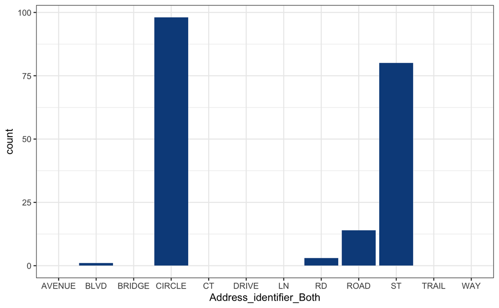

```r
ggplot(BothData) +
 aes(x = Address_identifier_Both, weight = Count_Both) +
 geom_bar(fill = "#0c4c8a") +
 theme_bw()
```

### Your Turn #2: use ggplot to construct a bar chart in descending order of popularity for the street name identifiers you found for Address

```r
DR<-
Addresses%>%
  filter(grepl( "DR", address))%>%
  summarise(total=n())
DR
```

| total |
| --- |
| 948 |

```r
AVE<-
Addresses%>%
  filter(grepl( "AVE", address))%>%
  summarise(total=n())
AVE
```

| total |
| --- |
| 298 |

```r
RD<-
Addresses%>%
  filter(grepl( "RD", address))%>%
  summarise(total=n())
RD
```

| total |
| --- |
| 846 |

```r
ST<-
Addresses%>%
  filter(grepl( "ST", address))%>%
  summarise(total=n())
ST
```

| total |
| --- |
| 984 |

```r
ROAD<-
Addresses%>%
  filter(grepl( "ROAD", address))%>%
  summarise(total=n())
ROAD
```

| total |
| --- |
| 220 |

```r
CIRCLE<-
Addresses%>%
  filter(grepl( "CIRCLE", address))%>%
  summarise(total=n())
CIRCLE
```

| total |
| --- |
| 67 |

```r
BLVD<-
Addresses%>%
  filter(grepl( "BLVD", address))%>%
  summarise(total=n())
BLVD
```

| total |
| --- |
| 61 |

```r
CT<-
Addresses%>%
  filter(grepl( "CT", address))%>%
  summarise(total=n())
CT
```

| total |
| --- |
| 254 |

```r
TRAIL<-
Addresses%>%
  filter(grepl( "TRAIL", address))%>%
  summarise(total=n())
TRAIL
```

| total |
| --- |
| 29 |

```r
LN<-
Addresses%>%
  filter(grepl( "LN", address))%>%
  summarise(total=n())
LN
```

| total |
| --- |
| 177 |

```r
AVENUE<-
Addresses%>%
  filter(grepl( "AVENUE", address))%>%
  summarise(total=n())
AVENUE
```

| total |
| --- |
| 58 |

```r
WAY<-
Addresses%>%
  filter(grepl( "WAY", address))%>%
  summarise(total=n())
WAY
```

| total |
| --- |
| 165 |

```r
Count_a<-c(948,298,846,984,220,67,61,254,29,177,58,165)
Address_identifier_a<-c("ST","RD","ROAD","CIRCLE","BLVD","CT","TRAIL","LN","AVENUE","BRIDGE","WAY","DRIVE")
Address_combine <- data.frame(Address_identifier_a,Count_a)
Address_combine%>%
  arrange(desc(Count_a))
```

| Address_identifier_a | Count_a |
| --- | --- |
| CIRCLE | 984 |
| ST | 948 |
| ROAD | 846 |
| RD | 298 |
| LN | 254 |
| BLVD | 220 |
| BRIDGE | 177 |
| DRIVE | 165 |
| CT | 67 |
| TRAIL | 61 |

[output cut: 2 more lines]

```r
DR<-
medicareService%>%
  filter(grepl( "DR", address))%>%
  summarise(total=n())
DR
```

| total |
| --- |
| 107682 |

```r
AVE<-
medicareService%>%
  filter(grepl( "AVE", address))%>%
  summarise(total=n())
AVE
```

| total |
| --- |
| 185821 |

```r
RD<-
medicareService%>%
  filter(grepl( "RD", address))%>%
  summarise(total=n())
RD
```

| total |
| --- |
| 159798 |

```r
ST<-
medicareService%>%
  filter(grepl( "ST", address))%>%
  summarise(total=n())
ST
```

| total |
| --- |
| 327780 |

```r
ROAD<-
medicareService%>%
  filter(grepl( "ROAD", address))%>%
  summarise(total=n())
ROAD
```

| total |
| --- |
| 24359 |

```r
CIRCLE<-
medicareService%>%
  filter(grepl( "CIRCLE", address))%>%
  summarise(total=n())
CIRCLE
```

| total |
| --- |
| 1310 |

```r
BLVD<-
medicareService%>%
  filter(grepl( "BLVD", address))%>%
  summarise(total=n())
BLVD
```

| total |
| --- |
| 68297 |

```r
CT<-
medicareService%>%
  filter(grepl( "CT", address))%>%
  summarise(total=n())
CT
```

| total |
| --- |
| 13278 |

```r
TRAIL<-
medicareService%>%
  filter(grepl( "TRAIL", address))%>%
  summarise(total=n())
TRAIL
```

| total |
| --- |
| 625 |

```r
LN<-
medicareService%>%
  filter(grepl( "LN", address))%>%
  summarise(total=n())
LN
```

| total |
| --- |
| 15423 |

```r
AVENUE<-
medicareService%>%
  filter(grepl( "AVENUE", address))%>%
  summarise(total=n())
AVENUE
```

| total |
| --- |
| 11220 |

```r
WAY<-
medicareService%>%
  filter(grepl( "WAY", address))%>%
  summarise(total=n())
WAY
```

| total |
| --- |
| 35286 |

```r
Count_m<-c(107682,185821,159798,327780,24359,1310,68297,13278,
625,15423,11220,35286)
Address_identifier_m<-c("ST","RD","ROAD","CIRCLE","BLVD","CT","TRAIL","LN","AVENUE","BRIDGE","WAY","DRIVE")
medicare_combine <- data.frame(Address_identifier_m,Count_m)
medicare_combine%>%
  arrange(desc(Count_m))
```

| Address_identifier_m | Count_m |
| --- | --- |
| CIRCLE | 327780 |
| RD | 185821 |
| ROAD | 159798 |
| ST | 107682 |
| TRAIL | 68297 |
| DRIVE | 35286 |
| BLVD | 24359 |
| BRIDGE | 15423 |
| LN | 13278 |
| WAY | 11220 |

[output cut: 2 more lines]

### identifier graph of medicare source

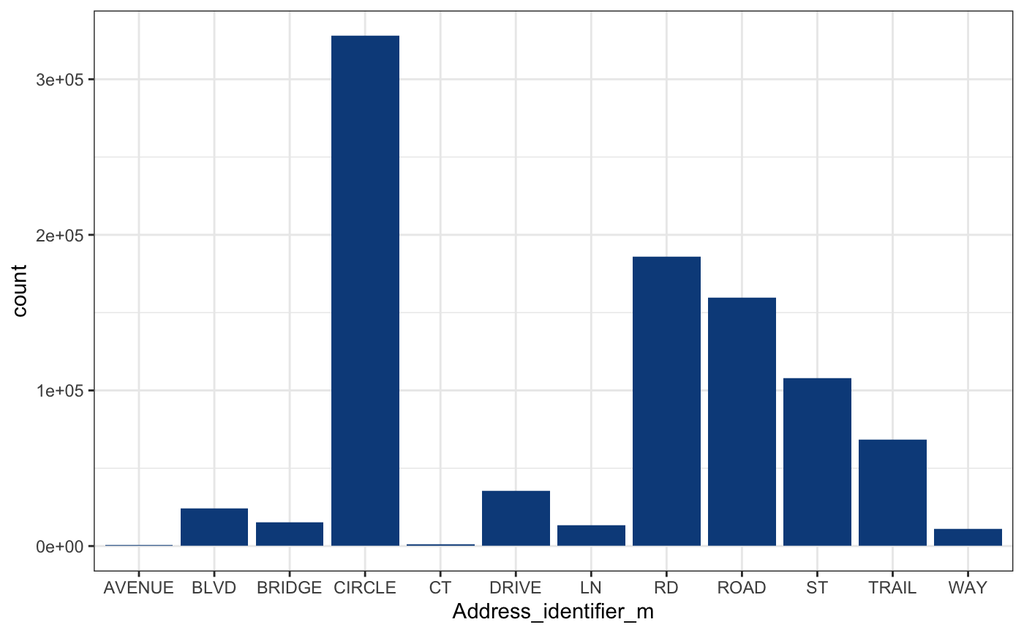

```r
ggplot(medicare_combine) +
 aes(x = Address_identifier_m, weight = Count_m) +
 geom_bar(fill = "#0c4c8a") +
 theme_bw()
```

### identifier graph of address source

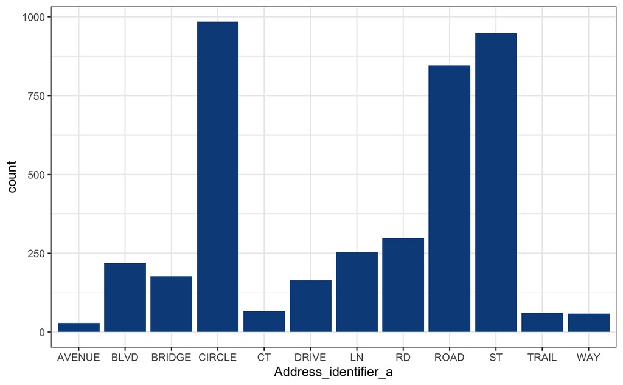

```r
ggplot(Address_combine) +
 aes(x = Address_identifier_a, weight = Count_a) +
 geom_bar(fill = "#0c4c8a") +
 theme_bw()
```